# Trabalho Final

Ana Luiza Garcia e Roubean Jhandson Gomes

25/11/2019

**1) Modelos de suavização exponencial**

**a) Crie um objeto em R para a série temporal, com as partições pré e pós evento.**

Criando um objeto em R para série temporal pré-evento:

```r
library(fpp2)
```

```r
library(ggplot2)
library(readxl)
trabalho_final_Set11_aereo <- read_excel("C:/Users/analu/Downloads/trabalho_final_Set11_aereo.xls")
dados <- trabalho_final_Set11_aereo

str(dados)
```

```
## Classes 'tbl_df', 'tbl' and 'data.frame':    172 obs. of  2 variables:
##  $ Mês           : POSIXct, format: "1990-01-01" "1990-02-01" ...
##  $ Air RPM (000s): num  35153577 32965187 39993913 37981886 38419672 ...
```

```r
dados1 <-  dados[,-1]
str(dados)
```

```
## Classes 'tbl_df', 'tbl' and 'data.frame':    172 obs. of  2 variables:
##  $ Mês           : POSIXct, format: "1990-01-01" "1990-02-01" ...
##  $ Air RPM (000s): num  35153577 32965187 39993913 37981886 38419672 ...
```

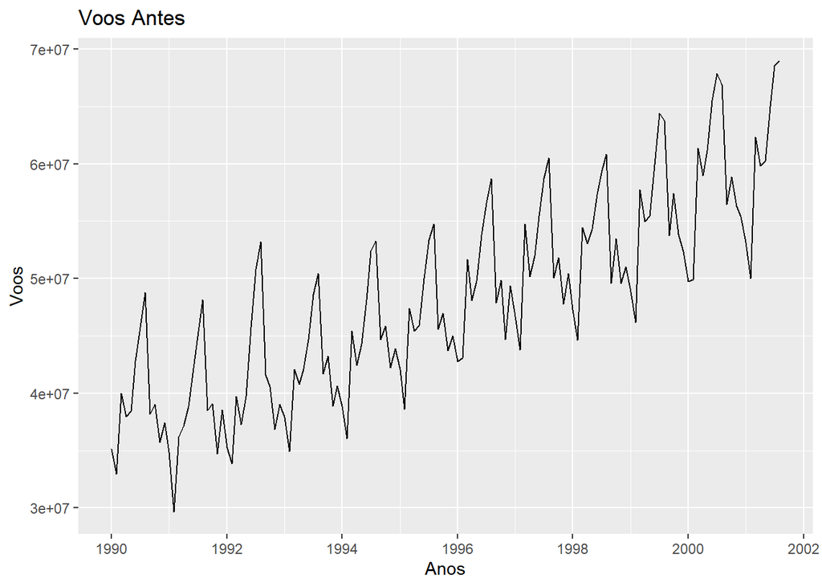

```r
tsdados <- ts(dados1, start = c(1990,1), frequency=12)
tsantes <- window(tsdados, end= c(2001,8))
autoplot(tsantes, ylab = "Voos", xlab = "Anos", main = "Voos Antes")
```

Criando um objeto em R para série temporal pós-evento:

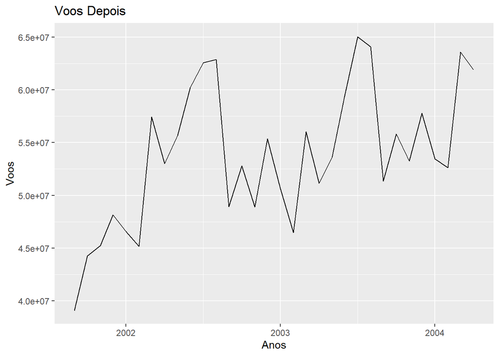

```r
tsdepois<- window(tsdados, start= c(2001,9))
autoplot(tsdepois, ylab = "Voos", xlab = "Anos", main = "Voos Depois")
```

**b) Analise o comportamento dos dados, e tente definir que componentes estão presentes.**

Analisando-se os dados apresentados no gráfico de “Voos Antes”, é notória uma tendência ascendente (pois os valores crescem) e é sazonal, pois o padrão repete-se anualmente.

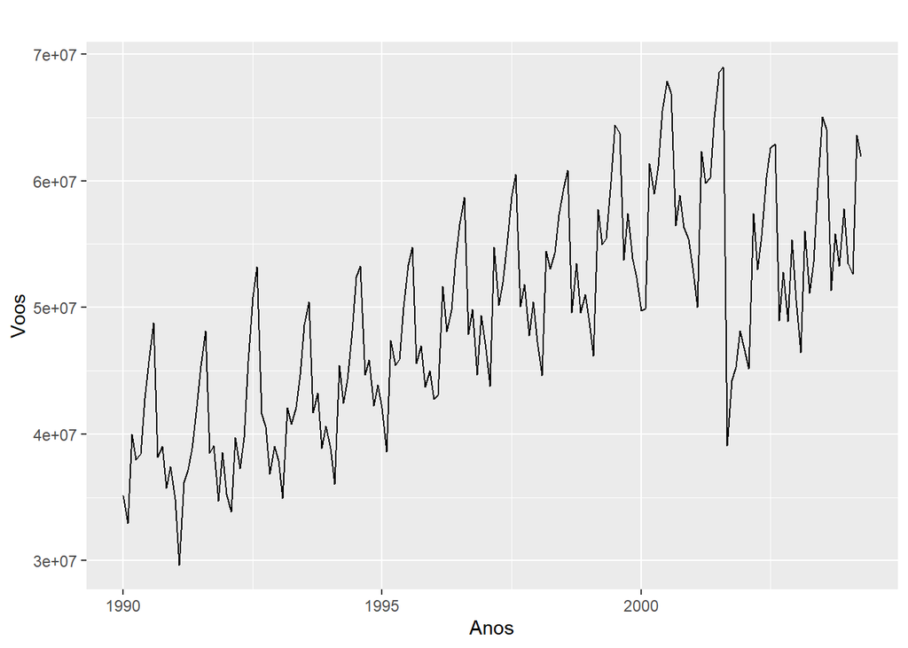

```r
autoplot(tsdados, ylab = "Voos", xlab = "Anos")
```

Através do gráfico anterior, nota-se uma queda repentina pós-evento, indicativo forte de que o 11 de setembro influenciou nos números de vôos.

**(c) Escolha um método de suavização/ETS que mais se adeque aos dados. Explique a sua escolha.**

Para solucionarmos essa etapa, utilizaremos diversos modelos que buscarão prever os futuros dados de acordo com os números apresentados antes do evento. A qualidade dos modelos será analisada através dos erros obtidos em cada um. O que apresentar o menor erro, será selecionado.

Aplicando Modelo de Holt

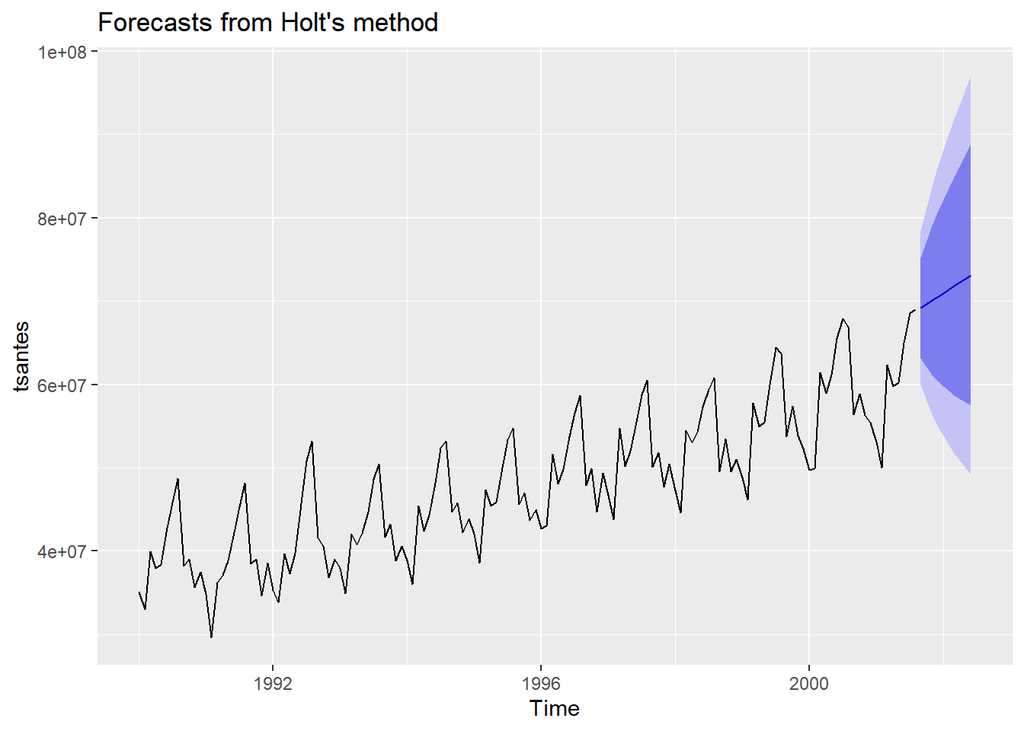

```r
holt1<- holt(tsantes)

autoplot(holt1)
```

```r
accuracy(holt1)
```

```
##                     ME    RMSE     MAE       MPE     MAPE     MASE
## Training set -435071.8 4634942 3560545 -1.619605 7.675169 1.621641
##                     ACF1
## Training set -0.01212776
```

Aplicando Modelo Holt Winters

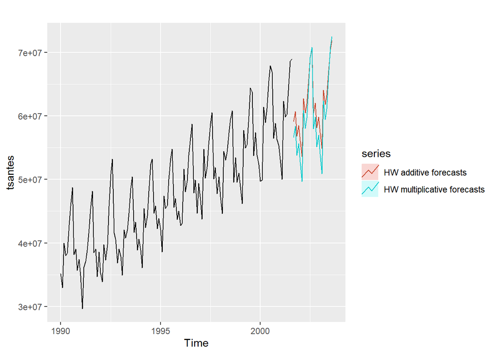

```r
hw1 <- hw(tsantes, seasonal = "additive")
hw2 <- hw(tsantes, seasonal = "multiplicative")

autoplot(tsantes) +
  autolayer(hw1, series="HW additive forecasts", PI=FALSE) +
  autolayer(hw2, series="HW multiplicative forecasts",PI=FALSE)
```

```r
accuracy(hw1)
```

```
##                    ME    RMSE      MAE        MPE     MAPE      MASE
## Training set 60770.97 1205412 882846.5 0.06434758 1.885605 0.4020903
##                    ACF1
## Training set 0.08764919
```

```r
accuracy(hw2)
```

```
##                    ME    RMSE    MAE         MPE   MAPE      MASE
## Training set 14099.78 1188410 885124 -0.00333065 1.8861 0.4031276
##                     ACF1
## Training set -0.01503244
```

Decompondo sazonalidade, tendencia e nível.

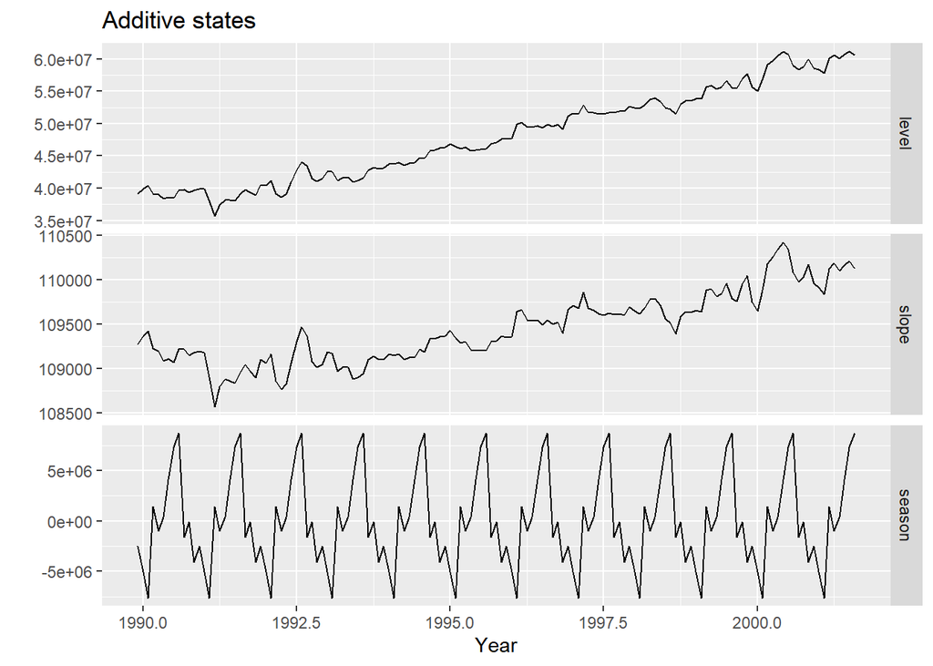

```r
addstates <- hw1$model$states[,1:3]
multstates <- hw2$model$states[,1:3]
colnames(addstates) <- colnames(multstates) <- c("level","slope","season")
p1 <- autoplot(addstates, facets=TRUE) + xlab("Year") + ylab("") +
  ggtitle("Additive states")
p2 <- autoplot(multstates, facets=TRUE) + xlab("Year") + ylab("") +
  ggtitle("Multiplicative states")
plot(p1)
```

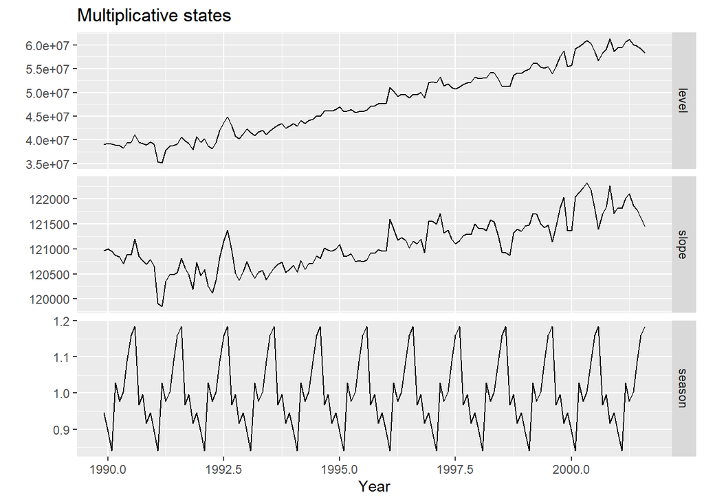

```r
plot(p2)
```

Aplicando Modelo ETS

```r
ets1<- ets(tsantes)
ets1$mse
```

```
## [1] 1.453019e+12
```

```r
summary(ets1)
```

```
## ETS(A,A,A)
##
## Call:
##  ets(y = tsantes)
##
##   Smoothing parameters:
##     alpha = 0.7152
##     beta  = 1e-04
##     gamma = 1e-04
##
##   Initial states:
##     l = 39161830.4465
##     b = 109272.4511
##     s = -2532919 -4081287 -96457.24 -1600474 8682759 7370005
##            4129650 376224.2 -988557.9 1416430 -7637994 -5037381
##
##   sigma:  1280822
##
##      AIC     AICc      BIC
## 4646.483 4651.499 4696.491
##
## Training set error measures:
##                    ME    RMSE    MAE        MPE     MAPE      MASE
## Training set 60777.29 1205412 882853 0.06435718 1.885615 0.4020932
##                    ACF1
## Training set 0.08770219
```

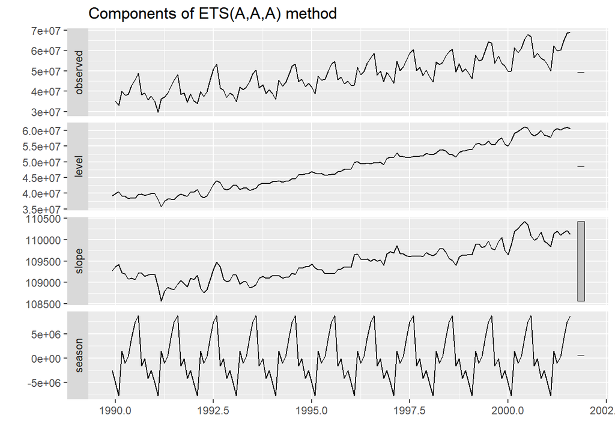

```r
autoplot(ets1)
```

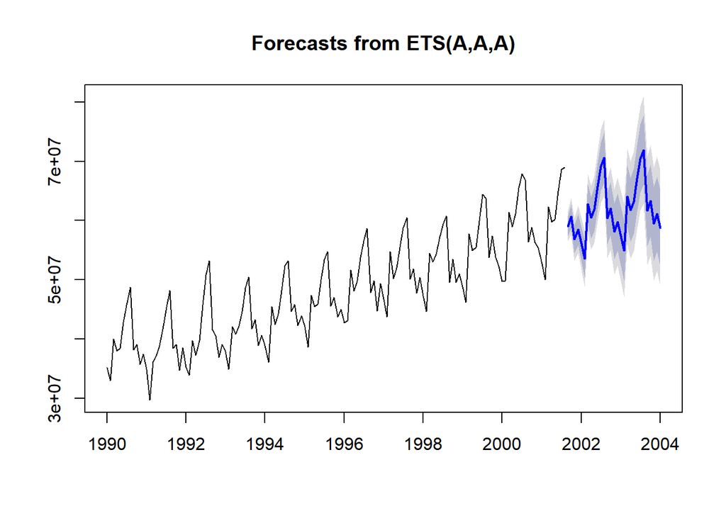

```r
plot(forecast(ets1, h=29))
```

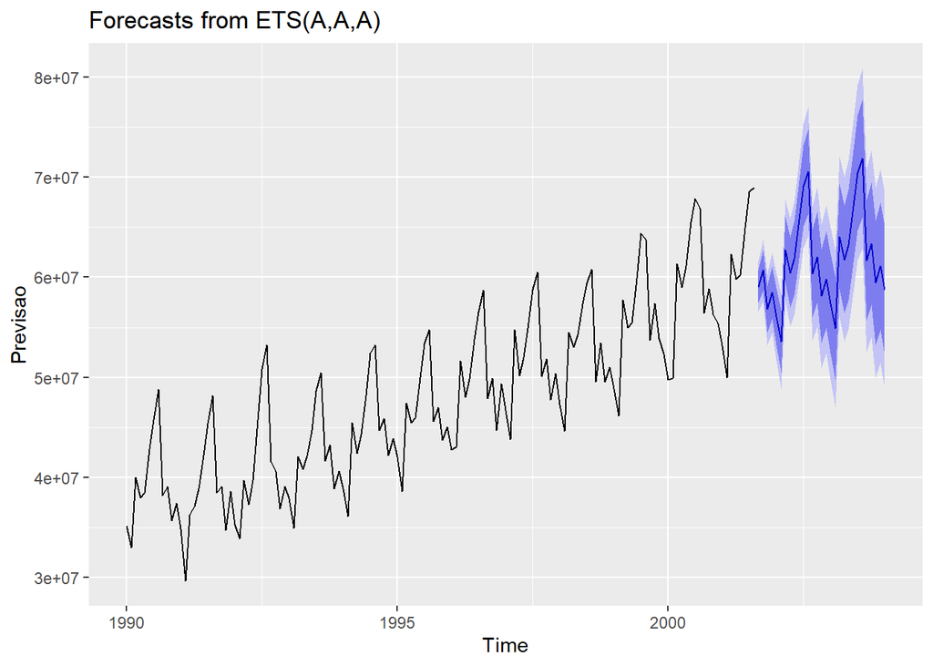

```r
ets1 %>% forecast(h=29) %>%
  autoplot() +
  ylab("Previsao")
```

```r
accuracy(ets1)
```

```
##                    ME    RMSE    MAE        MPE     MAPE      MASE
## Training set 60777.29 1205412 882853 0.06435718 1.885615 0.4020932
##                    ACF1
## Training set 0.08770219
```

Após a análise dos números apresentados, escolheu-se utilizar o modelo Holt Winters (hw2).

**Segunda parte:**

Aplicando Modelo de Regressão + Tendência

```r
regts1 <- tslm(tsdados ~ trend + I(trend^2) + season)
regts2 <- tslm(tsdados ~ trend + season)

summary(regts1)
```

```
##
## Call:
## tslm(formula = tsdados ~ trend + I(trend^2) + season)
##
## Residuals:
##       Min        1Q    Median        3Q       Max
## -13711310  -1594842    -50956   1702689   6054565
##
## Coefficients:
##               Estimate Std. Error t value Pr(>|t|)
## (Intercept) 30421335.9   986741.5  30.830  < 2e-16 ***
## trend         231216.1    18313.4  12.626  < 2e-16 ***
## I(trend^2)      -591.4      102.5  -5.767 4.13e-08 ***
## season2     -2491283.9  1079782.2  -2.307 0.022341 *
## season3      6873819.7  1079810.9   6.366 2.01e-09 ***
## season4      4212311.3  1079858.7   3.901 0.000142 ***
## season5      5244928.3  1099469.2   4.770 4.15e-06 ***
## season6      9303565.8  1099460.6   8.462 1.68e-14 ***
## season7     12695851.0  1099464.4  11.547  < 2e-16 ***
## season8     13686812.2  1099480.5  12.448  < 2e-16 ***
## season9      1552453.9  1099508.7   1.412 0.159930
## season10     3700808.4  1099549.0   3.366 0.000958 ***
## season11      182884.1  1099601.5   0.166 0.868119
## season12     2399464.7  1099666.4   2.182 0.030587 *
## ---
## Signif. codes:  0 '***' 0.001 '**' 0.01 '*' 0.05 '.' 0.1 ' ' 1
##
## Residual standard error: 2957000 on 158 degrees of freedom
## Multiple R-squared:  0.8909, Adjusted R-squared:  0.8819
## F-statistic:  99.2 on 13 and 158 DF,  p-value: < 2.2e-16
```

```r
summary(regts2)
```

```
##
## Call:
## tslm(formula = tsdados ~ trend + season)
##
## Residuals:
##       Min        1Q    Median        3Q       Max
## -14083874  -1608779    268312   1965191   6519382
##
## Coefficients:
##             Estimate Std. Error t value Pr(>|t|)
## (Intercept) 33255186     938469  35.436  < 2e-16 ***
## trend         128909       4984  25.862  < 2e-16 ***
## season2     -2490101    1184257  -2.103 0.037070 *
## season3      6875003    1184289   5.805 3.39e-08 ***
## season4      4212311    1184341   3.557 0.000495 ***
## season5      5444812    1205250   4.518 1.21e-05 ***
## season6      9506997    1205219   7.888 4.64e-13 ***
## season7     12901648    1205209  10.705  < 2e-16 ***
## season8     13893792    1205219  11.528  < 2e-16 ***
## season9      1759434    1205250   1.460 0.146316
## season10     3906606    1205301   3.241 0.001450 **
## season11      386316    1205374   0.320 0.749014
## season12     2599348    1205466   2.156 0.032563 *
## ---
## Signif. codes:  0 '***' 0.001 '**' 0.01 '*' 0.05 '.' 0.1 ' ' 1
##
## Residual standard error: 3243000 on 159 degrees of freedom
## Multiple R-squared:  0.8679, Adjusted R-squared:  0.8579
## F-statistic: 87.04 on 12 and 159 DF,  p-value: < 2.2e-16
```

**Terceira Parte**

Depois de apresentados os melhores modelos, segue a previsão e o que efetivamente aconteceu:

Segundo a previsão:

```r
print(hw2)
```

```
##          Point Forecast    Lo 80    Hi 80    Lo 95    Hi 95
## Sep 2001       56554715 54555034 58554395 53496467 59612962
## Oct 2001       58355100 55501474 61208725 53990856 62719343
## Nov 2001       53795099 50599400 56990797 48907700 58682498
## Dec 2001       55626943 51828323 59425562 49817455 61436430
## Jan 2002       52723887 48710637 56737136 46586151 58861622
## Feb 2002       49681213 45547977 53814450 43359974 56002453
## Mar 2002       60861939 55402809 66321069 52512920 69210958
## Apr 2002       58010469 52456489 63564450 49516390 66504549
## May 2002       59667491 53616651 65718332 50413530 68921453
## Jun 2002       64778177 57862334 71694021 54201308 75355047
## Jul 2002       69243762 61499244 76988280 57399543 81087980
## Aug 2002       70776804 62517733 79035876 58145644 83407965
## Sep 2002       57964193 50931160 64997226 47208097 68720289
## Oct 2002       59806434 52283298 67329569 48300791 71312076
## Nov 2002       55130255 47958685 62301824 44162286 66098224
## Dec 2002       57004714 49353081 64656347 45302551 68706877
## Jan 2003       54027065 46558537 61495594 42604937 65449194
## Feb 2003       50906662 43671715 58141609 39841765 61971559
## Mar 2003       62360095 53262188 71458002 48446047 76274142
## Apr 2003       59435511 50546377 68324645 45840754 73030268
## May 2003       61130244 51769485 70491003 46814199 75446289
## Jun 2003       66362981 55970125 76755837 50468480 82257482
## Jul 2003       70934370 59584896 82283844 53576847 88291892
## Aug 2003       72501333 60660870 84341797 54392908 90609759
```

O que aconteceu:

```r
print (tsdepois)
```

```
##           Jan      Feb      Mar      Apr      May      Jun      Jul
## 2001
## 2002 46587818 45157533 57423155 53013066 55663570 60224150 62570110
## 2003 50602700 46455943 56033121 51146721 53591384 59426357 65041408
## 2004 53447972 52608801 63600019 61887720
##           Aug      Sep      Oct      Nov      Dec
## 2001          39106905 44271037 45245063 48167518
## 2002 62881793 48925997 52779975 48902677 55355434
## 2003 64095456 51347366 55810667 53249129 57795908
## 2004
```

O próprio mês de Setembro de 2001 foi severamente afetado. De acordo com a previsão do modelo, deveríamos ter mais de 55 milhões de voos. Entretando, de acordo com os dados verdadeiros, somente 39 milhões realmente aconteceram.

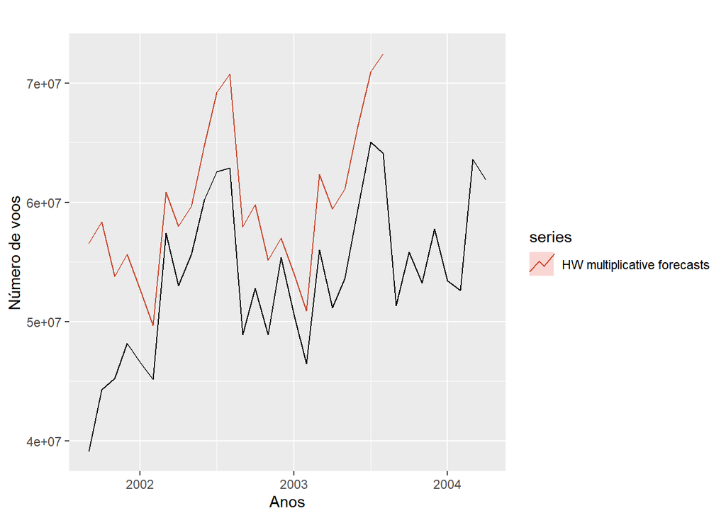

```r
autoplot(tsdepois, ylab = "Número de voos", xlab = "Anos" ) +
  autolayer(hw2, series="HW multiplicative forecasts",PI=FALSE)
```

Esse gráfico representa um comparativo do que efetivamente ocorreu (em preto) com o esperado pelo modelo (vermelho). Por volta de Março de 2002 o número de vôos quase retorna ao esperado pelo modelo, com uma diferença de 3 milhões. Fez-se notório, por conseguinte, que o evento influenciou o número de voos.